# Blended reporting at DZHW - A Guideline

Contribution to the DEiVHERSS competition 2023

Hartstein, J., Tcypina, A., Fabian, G.

# 1 Introduction

This guideline offers some solutions for reporting in Higher Education Research and Science Studies. It shows how to do blended reporting with DZHW corporate design colors with a focus on categorical data. The audience of this guideline are people who are familiar with R, but are first-timers in doing blended reporting with R for DZHW.

Some possibilities of RMarkdown (Allaire et al. 2023) are shown with data from EUROSTUDENT VII (Cuppen et al. 2023) and the DZHW Science Survey (Ambrasat et al. 2022) to illustrate typical visualization tasks in Higher Education Research and Science Studies. However, the visualization strategies and examples can be applied to other data sets. For a self contained and reproducible example, please refer to our template “Use corporate design with RMarkdown”.

The guideline is only tested on Windows, as Windows is widespread in use at DZHW.

# 2 Prepare your workspace

First of all, we define, how R code should be handled during rendering. We attach the libraries we intend to use (in this case tidyverse (Wickham et al. 2019), tictoc (Izrailev 2023), haven (Wickham, Miller, and Smith 2023), ggplot2 (Wickham 2016) and scales (Wickham and Seidel 2022). Also, we set the system language to English.

```r
library(tidyverse)
library(haven)
library(ggplot2)
library(scales)
```

Note: please do not forget to give credit to package authors, e.g. by citing the package properly in your reference list. You can get the recommended way of citing with ‘citation(“package”)’.

```r
citation("tidyverse")
```

```
##
##
##   Wickham H, Averick M, Bryan J, Chang W, McGowan LD, François R,
##   Grolemund G, Hayes A, Henry L, Hester J, Kuhn M, Pedersen TL, Miller
##   E, Bache SM, Müller K, Ooms J, Robinson D, Seidel DP, Spinu V,
##   Takahashi K, Vaughan D, Wilke C, Woo K, Yutani H (2019). "Welcome to
##   the tidyverse." _Journal of Open Source Software_, *4*(43), 1686.
##   doi:10.21105/joss.01686 <https://doi.org/10.21105/joss.01686>.
##
## A BibTeX entry for LaTeX users is
##
##   @Article{,
##     title = {Welcome to the {tidyverse}},
##     author = {Hadley Wickham and Mara Averick and Jennifer Bryan and Winston Chang and Lucy D'Agostino McGowan and Romain François and Garrett Grolemund and Alex Hayes and Lionel Henry and Jim Hester and Max Kuhn and Thomas Lin Pedersen and Evan Miller and Stephan Milton Bache and Kirill Müller a…
##     year = {2019},
##     journal = {Journal of Open Source Software},
##     volume = {4},
##     number = {43},
##     pages = {1686},
##     doi = {10.21105/joss.01686},
##   }
```

## 2.1 Use DZHW corporate design colors in plots

We will use the standard corporate identity color scheme of DZHW[^1] (provided via a company template folder), so we create a color palette accordingly.

```r
### DZHW-Palette
DZHWpalette <- c("#7ab52a", # grün
                 "#605f5f", # grau
                 "#097d95", # türkis
                 "#f69f26", # orange
                 "#79a0c0", # blaugrau
                 "#0069b2", # blau
                 "#b5163f", # rot
                 "#a9ca6c", # grün 70%
                 "#898686", # grau 70%
                 "#6f9fb2", # türkis 70%
                 "#fabd6e", # orange 70%
                 "#a4bad2", # blaugrau 70%
                 "#6c91ca", # blau 70%
                 "#ca626c", # rot 70%
                 "#d1e1b0", # grün 40%
                 "#b8b5b5", # grau 40%
                 "#b1c6d2", # türkis 40%
                 "#fddaaf", # orange 40%
                 "#cdd8e6", # blaugrau 40%
                 "#afbfe2", # blau 40%
                 "#e0a8a7" #rot 40%
)
```

# 3 First Example: Share of female students in fields of study (EUROSTUDENT VII)

## 3.1 State of reporting so far

A comprehensive source of visualisations from the EUROSTUDENT data sets can be found on the EUROSTUDENT website: (https://www.eurostudent.eu/). Main results are displayed in an [18-page poster series](https://www.eurostudent.eu/download_files/documents/EurostudentVII_poster.pdf), which contains 35 separate data visualizations, out of which 32 are bar charts (14 classic and 18 stacked) [^2]. Often, we find added layers of information about subgroups, minimum or maximum on top of the bar plot layer.

We will try to mimic the visualization below with the data available as scientific use file from FDZ-DZHW. The figure title on the poster reads

“Female students in selected fields of study | Share of female students (in %)”

Also, the figure caption reads:

“Data source: EUROSTUDENT VII, A.3.EUROSTUDENT question(s): 6.2 What is your sex? Deviations from EUROSTUDENT survey conventions: FI, IT, SE. Deviations from EUROSTUDENT standard target group: DE, IE, IT, PL. | Ochsenfeld,F. (2014). Why do women’s fields of study pay less? A test of devaluation, human capital, and gender role theory. European Sociological Review, 30(4), 536–548.”

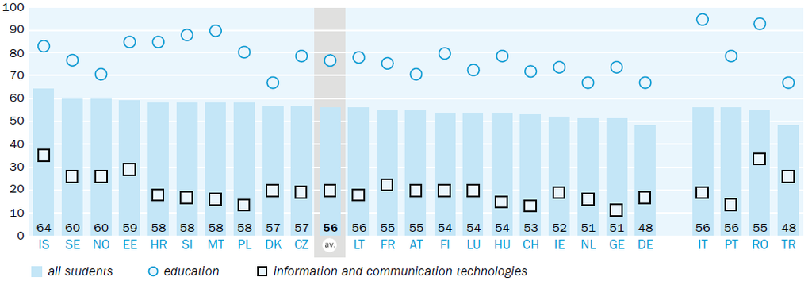

The underlying variables “country of survey” (variable name: “cntry”) and “what is your sex?” (variable name: “v6_2”) are categorical. We limit our attempts to the main data set (data for Norway was provided as a separate file and is therefore not incorporated into our data set).

## 3.2 Import and prepare your data

As data at DZHW is often stored or provided as STATA or SPSS files, which is especially true for the data sets we are using in this guideline, we use the package ‘haven’ (Wickham, Miller, and Smith 2023) to make the raw data fit for R. However, we will try not to use other functions of haven, because the guideline should in principle be applicable to any tabular data files.

```r
EUROSTUDENT_SUF <- read_dta("EUROSTUDENT_SUF.dta")
```

Additionally, we import a file with country-codes, which we will need later on to produce the figures accordingly.

```r
country_codes <- read.csv("country_codes.csv") %>%
  as_tibble()
```

We convert the data to factors with haven’s as_factor - this should default to only affect labelled columns. Also, we attach the country codes with an SQL-like join. Additionally, we save the variable labels as list for quick look ups.

```r
list_of_labels_EUROSTUDENT <- sapply(EUROSTUDENT_SUF, attr,"label")%>%
  as_tibble(rownames = "item") %>%
  rename("item_long" = "value")

EUROSTUDENT_SUF <- EUROSTUDENT_SUF %>%
  as_factor() %>%
  inner_join(country_codes, by = join_by(cntry == country_name))
```

## 3.3 Vertical stacked bar chart with short country labels

At first, we try to mimic the bar chart from the EUROSTUDENT poster. To construct this graphic, we reshape our data from long into wide format to compute group-wise shares.

```r
female_shares_wide <- EUROSTUDENT_SUF %>%
  select(country_code2, v6_2, v1_7) %>%
  droplevels()%>%
  pivot_wider(id_cols = country_code2, # reshape to wide format
              names_from = c(v6_2, v1_7),
              values_from = v6_2,
              values_fn = length,
              names_expand = TRUE)%>%
  mutate(sum_all = rowSums(across(where(is.numeric)), na.rm = TRUE), # insert rows for sums (all)
         sum_female = rowSums(across(starts_with("Female")), na.rm = TRUE),
         sum_education = rowSums(across(ends_with("Education")), na.rm = TRUE),
         sum_ICTs = rowSums(across(ends_with("ICTs")), na.rm = TRUE))%>%
  mutate(female_share_all = sum_female/sum_all, # insert rows for sums (female shares)
         female_share_education = Female_Education/sum_education,
         female_share_ICTs = Female_ICTs/sum_ICTs)%>%
  select(country_code2, # only choose relevant columns
         female_share_all,
         female_share_education,
         female_share_ICTs) %>%
  mutate(is_summary = 0) %>%
  add_row(country_code2 = "AV", # add average row
          female_share_all = mean(.$female_share_all),
          female_share_education = mean(.$female_share_education),
          female_share_ICTs = mean(.$female_share_ICTs),
          is_summary = 1)
```

This can then be plotted:

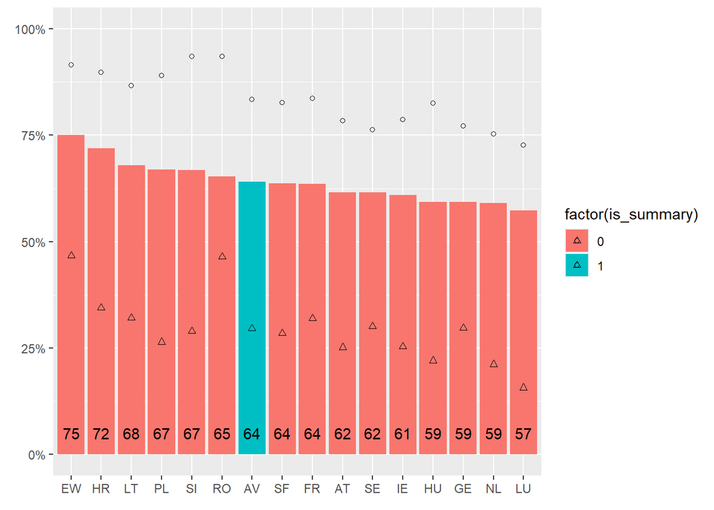

```r
female_shares_wide %>%
  ggplot(aes(x = reorder(country_code2, -female_share_all), # start plotting
             y = female_share_all,
             fill = factor(is_summary)))+
  geom_bar(stat = "Identity")+ # use bar chart
  scale_y_continuous(labels = scales::percent_format(accuracy = 1), limits = c(0,1)) + # format scale as percentages
  geom_text(aes(label = round(female_share_all, 2)*100, y = 0.05))+ # display shares as numbers
  geom_point(aes(y=female_share_education), shape = 1)+ # insert dots for field specific shares (education)
  geom_point(aes(y=female_share_ICTs), shape = 2)+ # insert dots for field specific shares (ICT)
  xlab(element_blank())+ # remove axis labels (x)
  ylab(element_blank()) # remove axis labels (y)
```

The only thing, which is missing, is the legend for the shapes. Which is unfortunate and also complicated. So, we have to go back to a long format. Note: Do not try this at home! It is never a good idea, to put proportions with different reference sets together in one table column. This is a catastrophe waiting to happen.

```r
female_shares_long <- female_shares_wide %>%
  pivot_longer(cols = !country_code2 & !is_summary,
               names_to = "fem_group",
               values_to = "fem_share")
```

Now, we can construct a plot with a proper legend. Also, we have now included the DZHW color scheme.

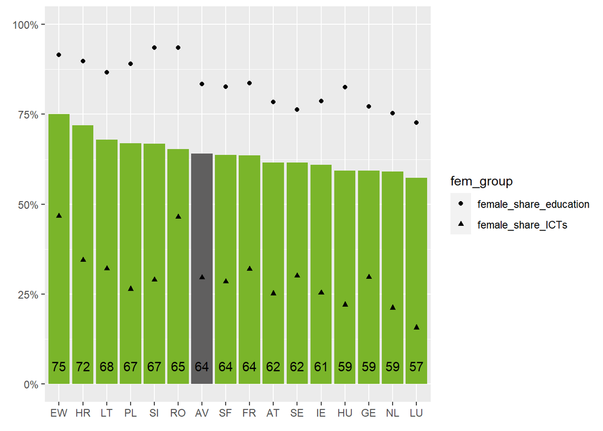

```r
female_shares_long %>%
  ggplot(aes(x = reorder(country_code2,-fem_share), # start the plot
             y = fem_share,
             fill = factor(is_summary)))+
  geom_bar(data = ~subset(., fem_group == "female_share_all"), # plot only field independent shares as bars
           stat = "Identity")+
  scale_y_continuous(labels = scales::percent_format(accuracy = 1), limits = c(0,1))+
  geom_text(data = ~subset(., fem_group == "female_share_all"),
            aes(label = round(fem_share, 2)*100, y = 0.05))+
  geom_point(data = ~subset(., fem_group != "female_share_all"), # plot only field specific shares as dots
             aes(shape = fem_group))+
  scale_fill_manual(values=c(DZHWpalette, DZHWpalette), guide = "none") + # use DZHW color scheme
  xlab(element_blank())+
  ylab(element_blank())
```

## 3.4 Remark on reproducibility and good practices

The image which we have produced is mimicking the original image from the poster series. However, the data set provided to us has different countries included than there are in the poster. Also, the numbers are not exactly the same, probably because of decisions, which were made during data preparation. We cannot really track these differences down, but would want to highlight, that code sharing could help to shed light on this issue.

## 3.5 Better solution to show female shares

The graphic provided on the posters can be improved in some ways:

- The country labels are difficult to decipher. While three-character country codes may be somewhat familiar to laymen audiences from sports contests, the two-character codes are probably not. Still, it would be preferable to avoid abbreviations in plot labels, if possible.
- To display female shares is an epistemic decision, which originates from a concept of gender which is binary. As the data show, we are already ahead of this traditional gender concept in some countries (Austria, Finland) judging by the data collection (i. e. choices available for participants). This should be reflected in the graphics (and also, will probably become more relevant in the future).
- To display the average value in between the other values is common in Social and Political Sciences as well as ordering the bars according to their values. However, ordering implies (e)valuation - which can be epistemically questionable in HERSS reporting. A fixed order (e. g. alphabetical) for countries could avoid that - and the average is better articulated as orthogonal dimension.
- Choosing to display sub-group values only for two fields is somewhat arbitrary. (Although, the data show that the two fields “ICTs” and “Education” are the most extreme cases of gender shares, which the poster does not explain.)

Better than to visualize only female shares (and thus biasing the reference frame for what is 100%) is probably to reflect all gender shares in a plot. To avoid having to abbreviate country labels, we go for a horizontal plot.

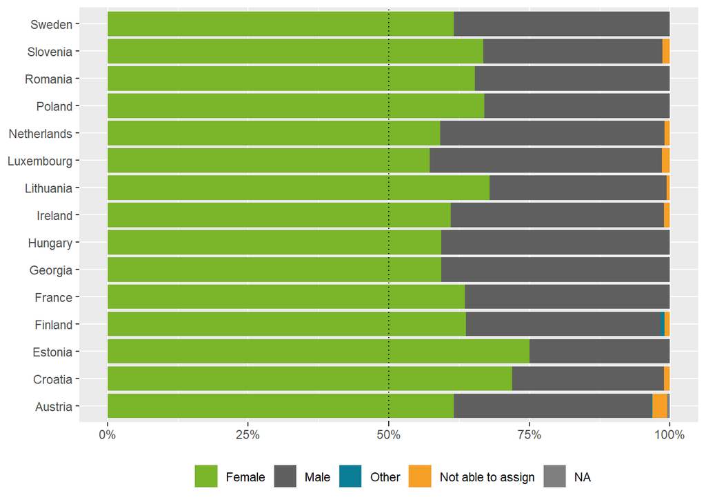

```r
female_shares_barplot <-
  EUROSTUDENT_SUF %>% # using the complete data set
  droplevels() %>% # dropping unused factor levels to achieve clean plot legends
  ### here, we begin to plot
  ggplot(
    aes( # defining the aesthetics
      x = cntry, # defining the independent variable
      #y = v6_2,
      fill = v6_2 # defining the color
    ))+
  ### this is where we add a barplot
  geom_bar(
    stat = "count", # bars show counts of values (is also the default)
    position = position_fill(reverse = TRUE) # make height of bars relative to the totals in x
    )+
  ### adjust how the information of bars is articulated
  scale_y_continuous(
    labels = scales::percent_format(accuracy = 1) # relabel the scales to percentages
    ) +
  geom_hline(
    yintercept =  0.5, linetype = "dotted" # insert 50%-line
             )+
  coord_flip(clip = 'off')+ # making barplot horizontal
  ### adjust plot to corporate identity
  scale_fill_manual(
    values=DZHWpalette # use corporate identity colors
    ) +
  ### the rest is design
  theme(
    legend.position = "bottom", # put the legend at the bottom
    legend.title=element_blank(), # remove legend title
    axis.title = element_blank() # remove axis titles
    )

female_shares_barplot
```

Afterwards, we can insert additional information about the average, which we need to compute first.

```r
female_share_countries_mean <-
  EUROSTUDENT_SUF %>%
  select(cntry, v6_2) %>%
  table() %>%
  prop.table(margin = "cntry") %>%
  as_tibble() %>%
  filter(v6_2 == "Female") %>%
  pull(n) %>%
  mean()
```

We do not need to compute the graphic completely anew, but just add a layer with “+”.

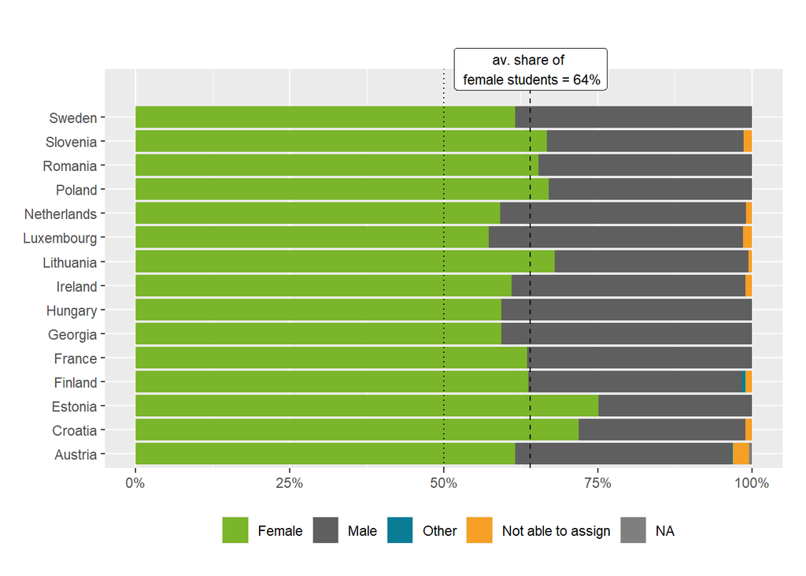

```r
female_shares_barplot + # use the plot already computed
  ### articulate mean share of female students
  geom_hline(
    yintercept =  female_share_countries_mean, linetype = "dashed" # insert average line
  )+
  annotate("label", x = 17, # insert label with average as number
           y = female_share_countries_mean,
           label = paste0("av. share of \n female students = ",
                          round(female_share_countries_mean, 2)*100,
                          "%"),
           size = 3
  )+
  theme(plot.margin = unit(c(3,1,1,1), "lines")) # make the plotting area larger so that the label is not cut
```

Or, we can display the gender shares by fieds of study

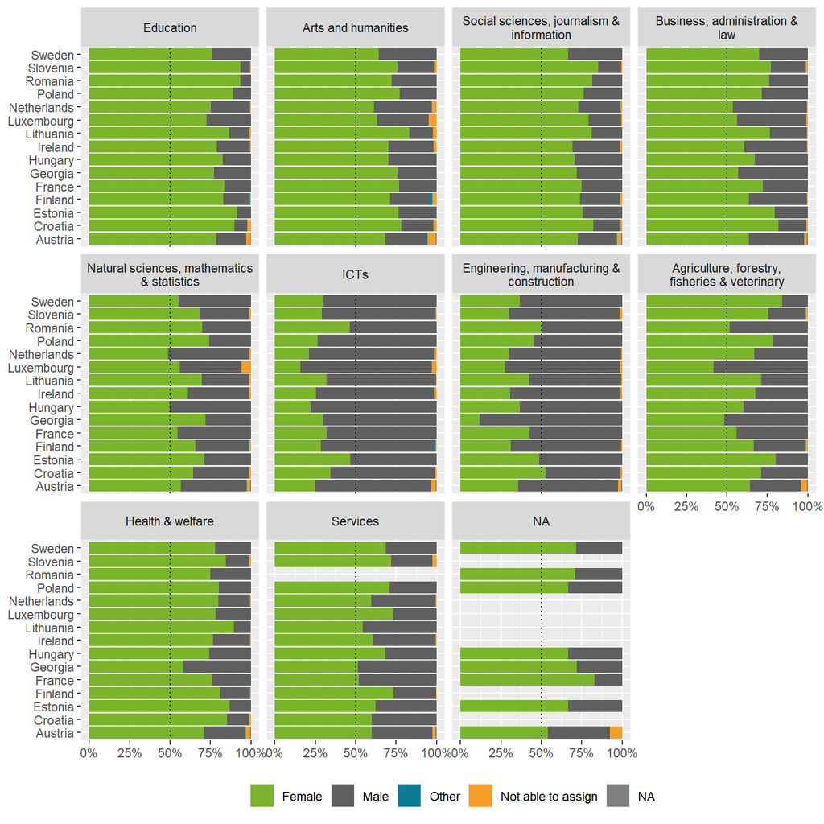

```r
female_shares_barplot +
facet_wrap(~v1_7,
           labeller = label_wrap_gen(30) # we let the labels wrap after a fixed number of characters
           )
```

# 4 Second example: Satisfaction being a researcher (DZHW Science Survey)

## 4.1 State of reporting so far

A comprehensive source of visualisations from the DZHW Science Survey data set can be found on the Science Survey website: (https://wb.dzhw.eu/). Main results are displayed in the report [“Barometer für die Wissenschaft”](https://www.wb.dzhw.eu/ergebnisse/index_html#barometer), which contains 38 separate data visualizations, out of which 21 are bar charts (18 classic and 3 stacked) [^3]. The second most prominent chart type are donut charts.

We will try to mimic one of the visualizations with data columns, which are also available with the scientific use file from FDZ-DZHW.

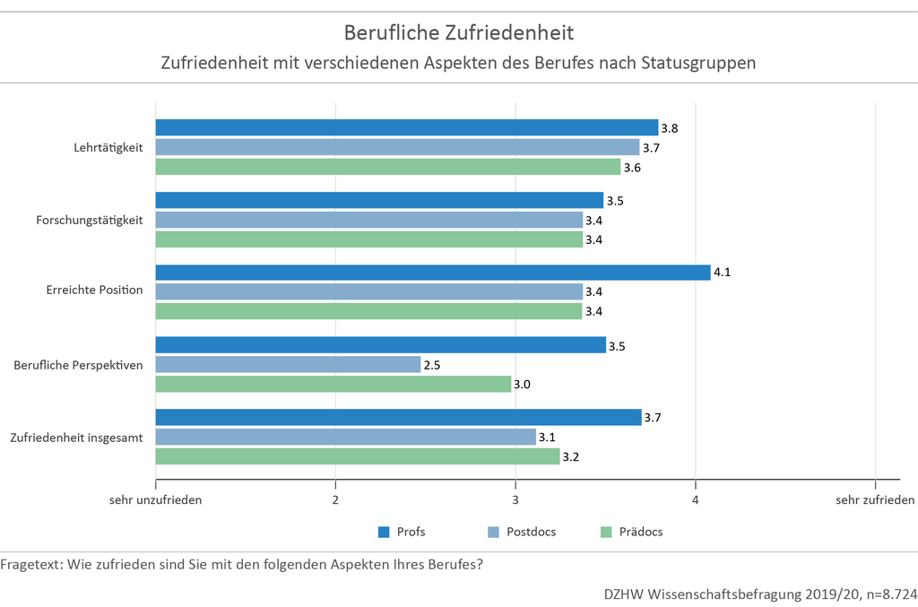

## 4.2 Import and prepare your data

Again, we use haven to import the STATA data set, make labelled columns to factors and create a list of labels for easy look up.

```r
#tic("importing data (WiBef)")
WiBef_SUF <- read_dta("WiBef_SUF.dta")

WiBef_SUF <- WiBef_SUF %>%
  as_factor()

list_of_labels_WiBef <- sapply(WiBef_SUF, attr,"label") %>%
  as_tibble()
#toc()
```

The columns in question are ordinal and are, until now, represented in the data set as factors. To compute means from them, we cast them to numeric values. Afterwards, we reshape the data to long format.

```r
satisfaction_long <- WiBef_SUF %>%
  mutate(fb11a_num = as.numeric(fb11a),
         fb11b_num = as.numeric(fb11b),
         fb11d_num = as.numeric(fb11d),
         fb11e_num = as.numeric(fb11e),
         fb11g_num = as.numeric(fb11g),
         ) %>%
  select(stgroup, fb11a_num, fb11b_num, fb11d_num, fb11e_num, fb11g_num) %>%
  pivot_longer(cols = !stgroup, names_to = "item", values_to = "value")
```

## 4.3 Horizontal grouped bar chart

This time, we do all our computations during plotting using the stat_summary function.

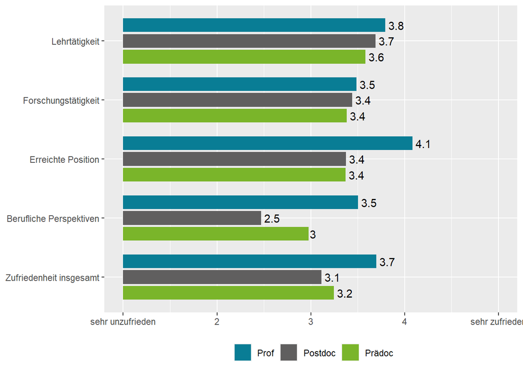

```r
satisfaction_long %>%
  ggplot(aes(x=fct_rev(item), # starting the plot (with factor levels reversed)
             y = value,
             fill = fct_rev(stgroup)))+
  geom_bar(position = position_dodge(0.8), width = 0.7, # bar chart with summary function
           stat = "summary", fun = "mean") +
  stat_summary(aes(label = round(..y.., 1), # insert the computed means as text
                   hjust = -0.2),
               position = position_dodge(0.8),
               geom = "text")+
  coord_flip()+ # make barplot horizontal
  scale_fill_manual(
    values=DZHWpalette, # use corporate color scheme
    guide = guide_legend(reverse = TRUE)) +
  theme(
    legend.position = "bottom", # put the legend at the bottom
    legend.title=element_blank(), # remove legend title
    axis.title = element_blank() # remove axis titles
    ) +
  scale_x_discrete(labels = c("Zufriedenheit insgesamt", # label the scale (x)
                              "Berufliche Perspektiven",
                              "Erreichte Position",
                              "Forschungstätigkeit",
                              "Lehrtätigkeit"))+
  scale_y_continuous(labels = c("sehr unzufrieden", 2,3,4, "sehr zufrieden"), # label the scale (y)
                     limits = c(1,5), # the default coordinate system would start at 0, but we need 1
                     oob = squish) # and the bars should start where the limit is
```

## 4.4 Remark on reproducibility and good practices

In the figure, we notice that our mean values fit with the values expressed in the report. However, in our plot, the bars represent the (more) exact computed values for the means whereas the annotation is given in rounded form. (E.g. is the satisfaction with research activity “Forschungstätigkeit” given as 3.4 for post-docs “Postdoc” and pre-docs “Prädoc”, but the bars are not exactly of the same length.) Seemingly, in the report, the rounded values are underlying the plot.

Moreover, due to recasting (and thus, renaming) of values to numeric, it does not work smoothly to map the variable names to the computed means, which is why they are written out explicitly in the code when creating the plot. This, clearly, is not ideal. And also, the labels are available in German only. We can hope for a better mapping in the future (and also, bilingual German/English, hopefully).

## 4.5 Satisfaction by field

Adapting the code from above, we can also compare the research fields against each other. We just have to use the field classification “dfg5” from our data set.

```r
satisfaction_long_fields <- WiBef_SUF %>%
  mutate(fb11a_num = as.numeric(fb11a),
         fb11b_num = as.numeric(fb11b),
         fb11d_num = as.numeric(fb11d),
         fb11e_num = as.numeric(fb11e),
         fb11g_num = as.numeric(fb11g),
         ) %>%
  select(stgroup, dfg5, fb11a_num, fb11b_num, fb11d_num, fb11e_num, fb11g_num) %>% # we add dfg5
  pivot_longer(cols = !stgroup & !dfg5, names_to = "item", values_to = "value") # we add dfg5
```

In the plot, we can then use facet_wrap again. Unfortunately, our handmade scale_x_discrete does not work like a charm, but would throw an error. As has been stated above, manual manipulation is bad practice.

It works slightly better, if we recode the factor levels of the categorial variables. And, while we are at it, we just relabel them in the language of our choice and put the info about the direction of scale in the figure caption.

The figure reveals, that the differences between research fields are very small - after all, researchers of different disciplines seem to have their satisfaction in common.

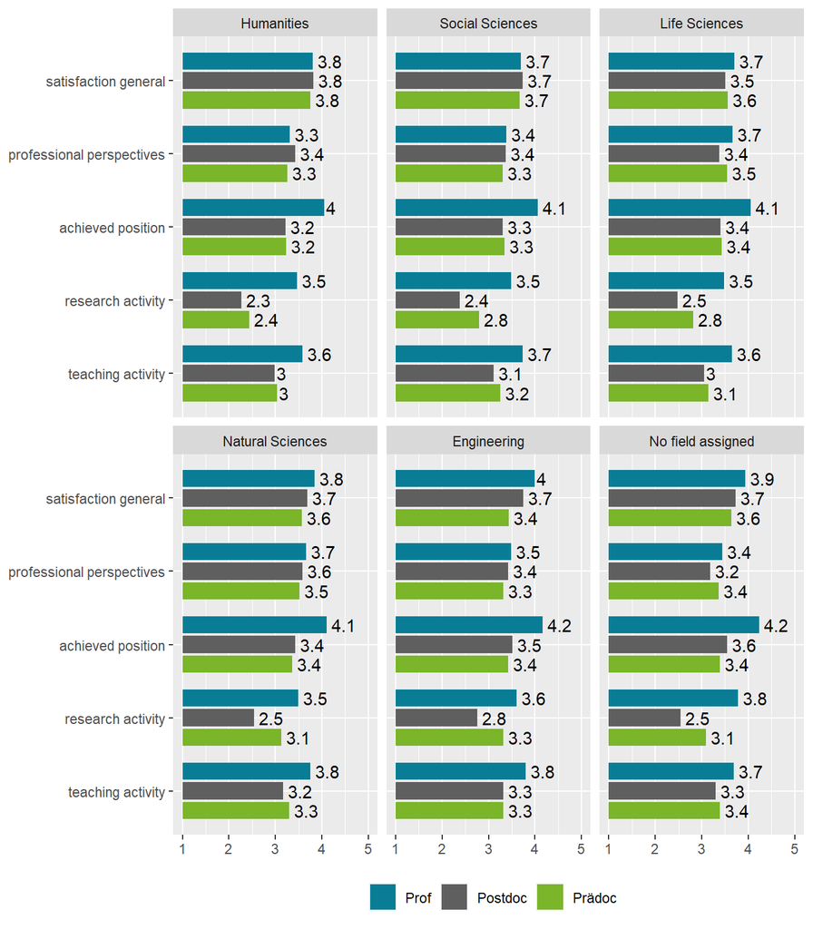

1 = very dissatisfied; 5 = very satisfied

```r
satisfaction_long_fields %>%
  mutate(item = fct_recode(item,
                           "satisfaction general" = "fb11a_num",
                           "professional perspectives" = "fb11b_num",
                           "achieved position" = "fb11d_num",
                           "research activity" = "fb11e_num",
                           "teaching activity" = "fb11g_num"),
         dfg5 = fct_recode(dfg5,
                              "Humanities" = "Geisteswissenschaften",
                              "Social Sciences" ="Sozialwissenschaften",
                              "Life Sciences" = "Lebenswissenschaften",
                              "Natural Sciences" = "Naturwissenschaften",
                              "Engineering" = "Ingenieurswissenschaften",
                              "No field assigned" = "Ohne Zuordnung"
         )) %>%
  ggplot(aes(x=fct_rev(item), y = value, fill = fct_rev(stgroup)))+
  geom_bar(position = position_dodge(0.8), width = 0.7, stat = "summary", fun = "mean") +
  stat_summary(aes(label = round(..y.., 1),
                   hjust = -0.2),
               position = position_dodge(0.8),
               geom = "text")+
  coord_flip()+
  scale_fill_manual(
    values=DZHWpalette, # use corporate identity colors
    guide = guide_legend(reverse = TRUE)) +
  theme(
    legend.position = "bottom", # put the legend at the bottom
    legend.title=element_blank(), # remove legend title
    axis.title = element_blank() # remove axis titles
    ) +
  facet_wrap(~dfg5)+ # wrap according to fields
  scale_y_continuous(limits = c(1,5), # the default coordinate system would start at 0, but we need 1
                     oob = squish) # and the bars should start where the limit is
```

# 5 Use functions to reuse your plots

If you have a limited set of visualizations which should occur often in your report for different variables, you can make your plot into a function.

```r
stacked_bars_cross <- function(data, column1,column2, ...) { # we start a function
  data %>%
    droplevels() %>%
    ggplot(aes(x = {{ column2 }}, # to use the columns as column names, we wrap them in double curly braces
               fill = {{ column1}})) +
  geom_bar(stat = "count", # we start a bar chart
           position = position_fill(reverse = TRUE)) +
  scale_y_continuous(labels = scales::percent_format(accuracy = 1)) + # scale as percentages
  coord_flip() + # barplot as horizontal
  scale_fill_manual(values=DZHWpalette) +
  theme(legend.position = "bottom",
        legend.title=element_blank(),
        axis.title = element_blank())
}
```

The function can then be applied to your data set …

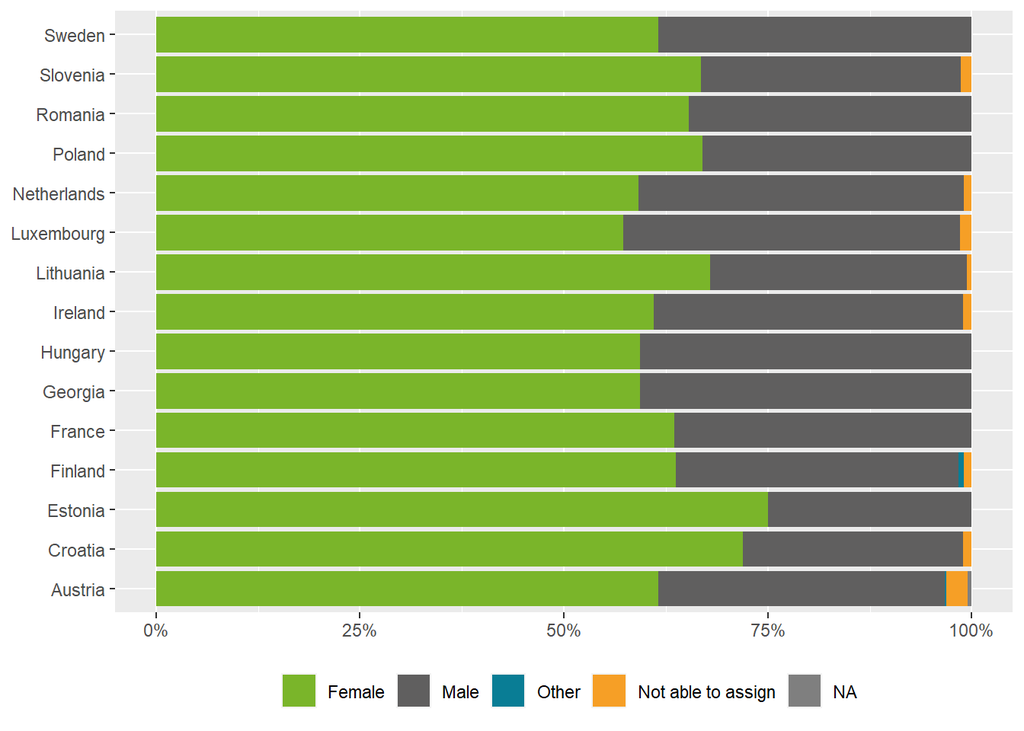

```r
p1 <- stacked_bars_cross(EUROSTUDENT_SUF, v6_2, cntry)

p1
```

… or your other data set (if the variables have the same type, which is here categorical).

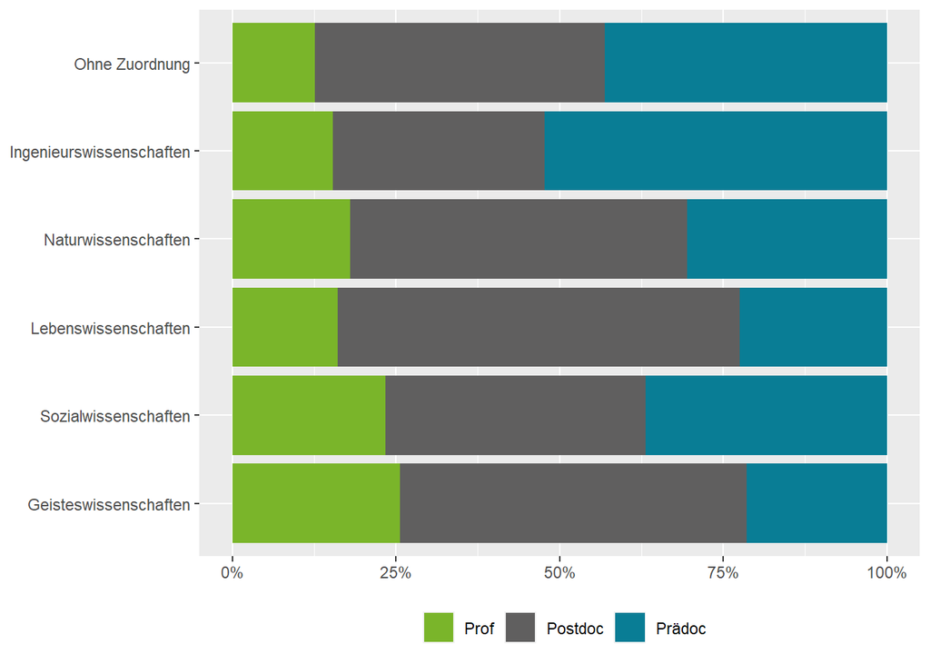

```r
p2 <- stacked_bars_cross(WiBef_SUF, stgroup, dfg5)

p2
```

You can add more layers as described above.

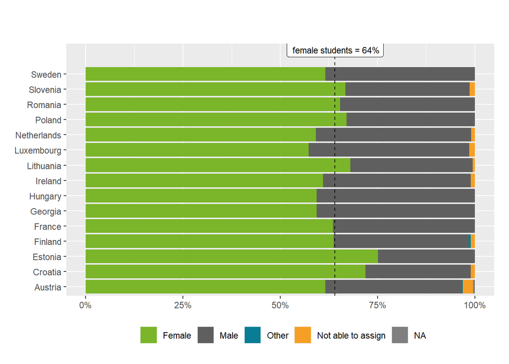

```r
p1 +
  geom_hline(yintercept =  female_share_countries_mean, linetype = "dashed")+
  annotate("label", x = 17, y = female_share_countries_mean,
           label = paste0("av. share of \n female students = ",
                          round(female_share_countries_mean, 2)*100,
                          "%"),
           size = 3)+
  theme(plot.margin = unit(c(3,1,1,1), "lines"))
```

You can wrap the figure by a third variable…

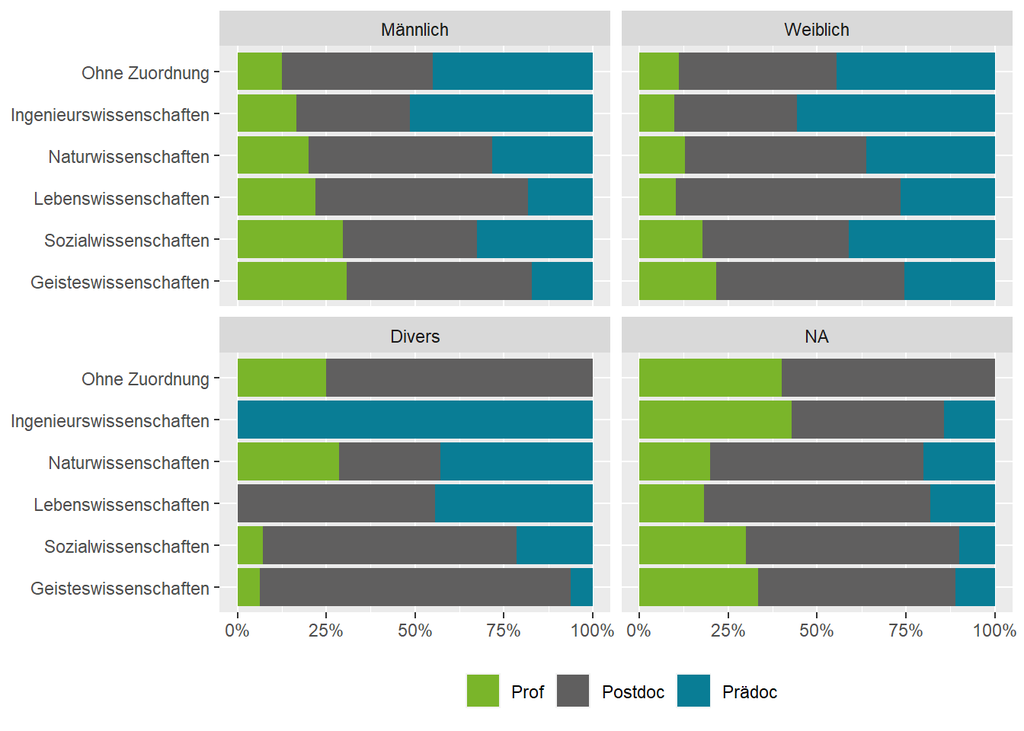

```r
p2 + facet_wrap(~de1)
```

… or you can also change the design completely using a different plot theme.

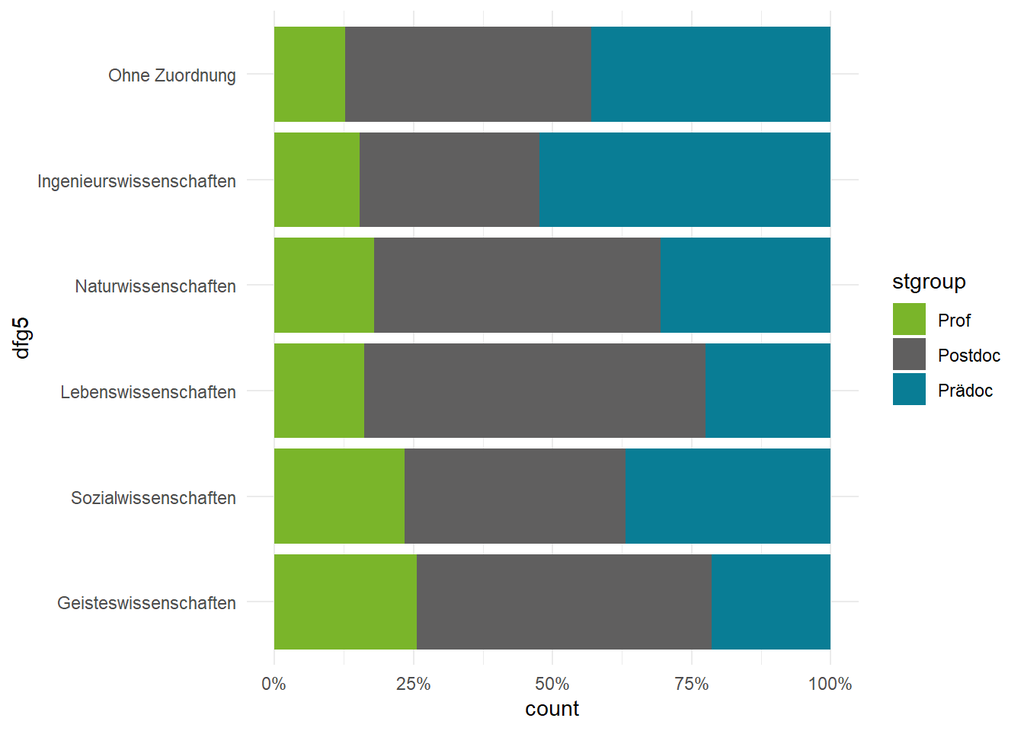

```r
p2 + theme_minimal()
```

# 6 More plots

## 6.1 Computations outside the plot

Sometimes, e.g. if you have complex computations, you will want to wrangle your data before plotting.

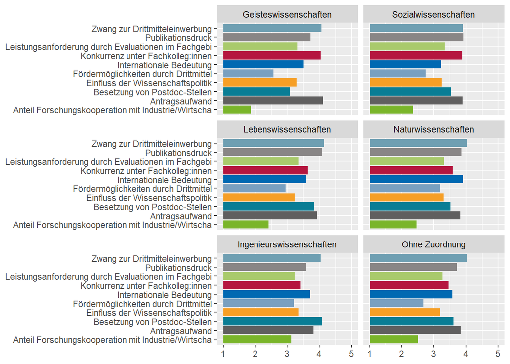

```r
WiBef_SUF %>%
  group_by(dfg5)%>%
  mutate(across(fa1:fa10, ~na_if(.x, "Kann ich nicht beurteilen")))%>%
  mutate(across(fa1:fa10, as.numeric))%>%
  summarise_at(vars(fa1:fa10), mean,na.rm=TRUE)%>%
  pivot_longer(cols = fa1:fa10, names_to = "item") %>%
  left_join(list_of_labels_WiBef) %>%
  # the plot starts here
  ggplot(aes(x=item_sub, y=value, fill = item_sub))+
  geom_bar(stat = "identity")+
  coord_flip(clip = "off")+
  theme(legend.position = "none",
        legend.direction = "vertical",
        legend.title = element_blank(),
        axis.title = element_blank())+
  facet_wrap(~dfg5, ncol = 2)+
  scale_fill_manual(values = DZHWpalette)+
  scale_y_continuous(limits = c(1,5), # the default coordinate system would start at 0, but we need 1
                     oob = squish) # and the bars should start where the limit is
```

## 6.2 Density plot

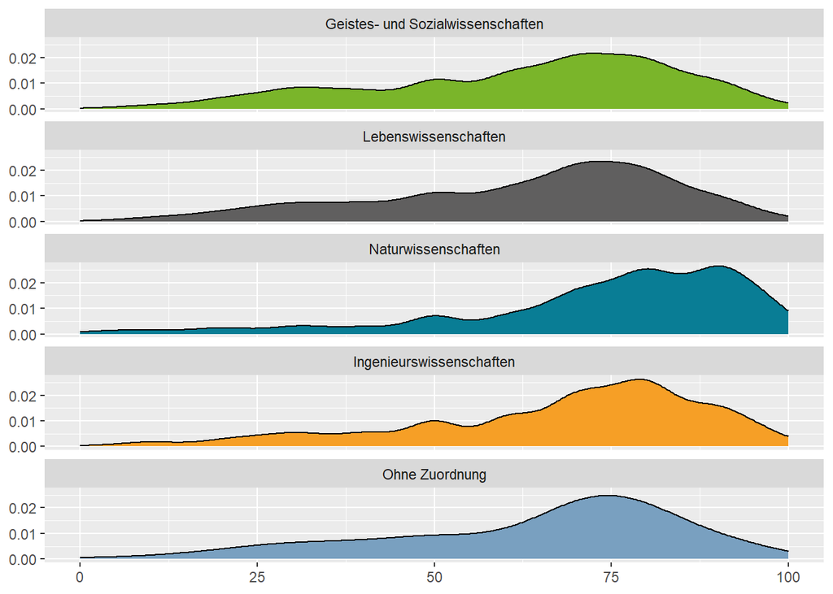

```r
WiBef_SUF %>%
  filter(fa11<=100)%>% # we remove the value "999", which is a code for NA values. participants had only to choose between 0 and 100
  ggplot(aes(group=dfg4, x=fa11, fill=dfg4)) +
  geom_density()+
  facet_wrap(~dfg4, ncol = 1)+
  theme(legend.position = "none", axis.title = element_blank())+
  scale_fill_manual(values = DZHWpalette)
```

## 6.3 Violin plot

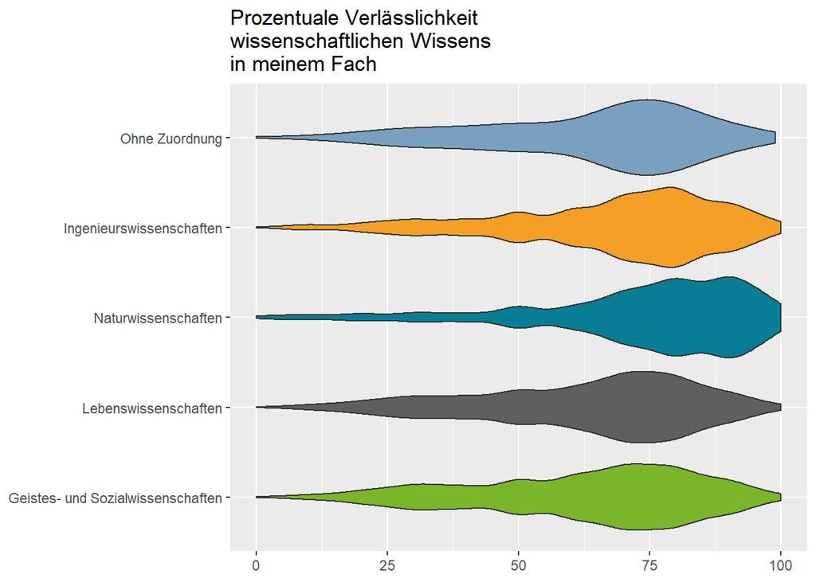

```r
WiBef_SUF %>%
  filter(fa11<=100)%>%
  ggplot(aes(x = dfg4, y = fa11, fill=dfg4))+
  geom_violin()+
  coord_flip()+
  theme(legend.position = "none")+
  scale_fill_manual(values = DZHWpalette)+
  #scale_color_manual(values = DZHWpalette)+
  theme(axis.title = element_blank())+
  ggtitle("Prozentuale Verlässlichkeit \nwissenschaftlichen Wissens \nin meinem Fach",)
```

# References

Allaire, JJ, Yihui Xie, Christophe Dervieux, Jonathan McPherson, Javier Luraschi, Kevin Ushey, Aron Atkins, et al. 2023. *Rmarkdown: Dynamic Documents for r*. https://github.com/rstudio/rmarkdown.

Ambrasat, Jens, Christophe Heger, Gregor Fabian, and Annegret Rucker. 2022. “DZHW-Wissenschaftsbefragung 2019. Datenerhebung: 2019/2020. Version: 2.0.0. Datenpaketzugangsweg: SUF: Remote-Desktop.” Edited by Anne Weber, Andreas Daniel, and Henrike Schmidtchen. Hannover: FDZ-DZHW. https://doi.org/10.21249/DZHW:scs2019:2.0.0.

Cuppen, Joris, Ardita Muja, Kristina Hauschildt, Andreas Daniel, Daniel Buck, Sylvia Mandl, and Martin Unger. 2023. “Eurostudent VII. Datenerhebung: 2019-2021. Version: 3.1.0. Datenpaketzugangsweg: SUF: Download.” Edited by Andreas Daniel, Daniel Buck, and Marten Wallis. Hannover: FDZ-DZHW. https://doi.org/10.21249/DZHW:es7:3.1.0.

Izrailev, Sergei. 2023. *Tictoc: Functions for Timing r Scripts, as Well as Implementations of "Stack" and "StackList" Structures*. https://CRAN.R-project.org/package=tictoc.

Wickham, Hadley. 2016. *Ggplot2: Elegant Graphics for Data Analysis*. Springer-Verlag New York. https://ggplot2.tidyverse.org.

Wickham, Hadley, Mara Averick, Jennifer Bryan, Winston Chang, Lucy D’Agostino McGowan, Romain François, Garrett Grolemund, et al. 2019. “Welcome to the tidyverse.” *Journal of Open Source Software* 4 (43): 1686. https://doi.org/10.21105/joss.01686.

Wickham, Hadley, Evan Miller, and Danny Smith. 2023. *Haven: Import and Export ’SPSS’, ’Stata’ and ’SAS’ Files*. https://CRAN.R-project.org/package=haven.

Wickham, Hadley, and Dana Seidel. 2022. *Scales: Scale Functions for Visualization*. https://CRAN.R-project.org/package=scales.

[^1]: credits to Petra Nölle
[^2]: Please find a quantitative evaluation of visualization types attached as supplementary material.
[^3]: Please find a quantitative evaluation of visualization types attached as supplementary material.